Introduction Microsimulation Machine Learning Models Reflection References

# Microsimulation Model (1) - ARP Child Tax Credit

## **Overview of the CTC under the American Rescue Plan Act**

**Accounting rules**

Maximum credit:

- $3000 per qualifying child between ages 6 and 17
- $3600 per qualifying child under age 6

Phase-out levels:

1. The available tax credit is reduced by $50 for each $1000 exceeding the income threshold below until the benefit reaches $2000 / child:
- $150,000 for married couples filing a joint return
- $75,000 for single filer or married couples filing separate returns
2. The available tax credit will not be reduced to below $2000 / child until the household income exceeds the threshold below:
- $400,000 for married couples filing a joint return
- $200,000 for all other filers

**Assumptions**

1. Ignore the first $75,000 of family income if there is a single parent and ignore the first $150,000 if there are (2) parents.
2. Create a maximum benefit of $3000 for children ages 6 and 17 and $3600 for children under 6.
3. Reduce the benefit by $50 for every $1000 of income in excess of $75,000 for single households and the same in excess of $150,000 for two-parent households until the maximum benefit hits $2000 / child. (For families with a single parent, the benefit is held constant at $95,000 - $200,000. For families with (2) parents, the benefit is held constant at $170,000 - $400,000)
4. Reduce the benefit by $50 for every $1000 in excess of $200,000 for single parent households and in excess of $400,000 for (2) parent households.

**Data loading and cleaning**

```r
# Loading in packages
library(tidymodels)
library(tidyverse)

# Loading in data

asec_2022 <-

  read_csv("/Users/mia.minkin/Downloads/Georgetown MPP/Classes/Year 2/Fall 2023/ds_2/final_project/data/asec_individual.csv") %>%

  # Subsetting to necessary variables

    filter(YEAR == 2022) %>%

  select(

    SERIAL,
    FTOTVAL,
    AGE,
    SEX,
    RACE,
    EMPSTAT,
    MARST,
    EDUC,
    NCHILD,
    NCHLT5,
    HWTFINL,
    WTFINL,
    ASECWTH) %>%

  filter(
    !FTOTVAL == "NA",
    !FTOTVAL < 0,
    !AGE < 18,
    !SEX == 9,
    !EMPSTAT == 00,
    !RACE == 999,
    !MARST == 9,
    !EDUC == 999,
    !EDUC == 000,
    !EDUC == 001) %>%

  mutate(
    MARST =
      case_when(
        MARST == 1 ~ 1,
        TRUE ~ 0)) %>%

  rename(
    label = SERIAL,
    hh_income = FTOTVAL,
    sex = SEX,
    marital_status = MARST,
    emp_status = EMPSTAT,
    age = AGE,
    race = RACE,
    education = EDUC,
    tot_children = NCHILD,
    young_children = NCHLT5) %>%

  mutate(
    old_children = tot_children - young_children) %>%

  distinct(label, .keep_all = TRUE)
```

## **Calculator function - ARP Child Tax Credit**

```r
#' Calculating the total child tax credit benefit for families under the American Rescue Plan Act's expanded child tax credit
#'
#' @param hh_income Numeric total of family income in a year
#' @param marital_status Binary variable for if parents are married or not
#' @param old_children Numeric total number of children 6 - 18
#' @param young_children Numeric total number of children under age 6
#'
#' @return Numeric benefit in dollars
#'

arpa_tax_credit <- function(hh_income, marital_status, old_children, young_children){

  # Assumption: Maximum income for full benefit = $75,000 if one head of household OR $150,000 if married household

  mod_income <-
    if_else(
      condition = marital_status == 1,
      true = pmax(hh_income - 150000, 0),
      false = pmax(hh_income - 75000, 0))

  # Benefit per child

  benefit <-

    case_when(

      # Married couple, income < 400k, only older children
      marital_status == 1 & hh_income < 400000 & old_children >= 1 & young_children == 0 ~
        pmax(2000, (3000 * old_children) - 0.05 * mod_income),

      # Married couple, income > 400k, only older children
      marital_status == 1 & hh_income > 400000 & old_children >= 1 & young_children == 0 ~
        pmax(0, (3000 * old_children) - 0.05 * mod_income),

      # Single household, income < 200k, only older children
      marital_status == 0 & hh_income < 200000 & old_children >= 1 & young_children == 0 ~
        pmax(2000, (3000 * old_children) - 0.05 * mod_income),

      # Single household, income > 200k, only older children
      marital_status == 0 & hh_income > 200000 & old_children >= 1 & young_children == 0 ~
        pmax(0, (3000 * old_children) - 0.05 * mod_income),

      # Married couple, income < 400k, only young children
      marital_status == 1 & hh_income < 400000 & old_children == 0 & young_children >= 1 ~
        pmax(2000, (3600 * young_children) - 0.05 * mod_income),

      # Married couple, income > 400k, only young children
      marital_status == 1 & hh_income < 400000 & old_children == 0 & young_children >= 1 ~
        pmax(0, (3600 * young_children) - 0.05 * mod_income),

      # Single household, income < 200k, only young children
      marital_status == 0 & hh_income < 200000 & old_children == 0 & young_children >= 1 ~
        pmax(2000, (3600 * young_children) - 0.05 * mod_income),

      # Single household, income > 200k, only young children
      marital_status == 0 & hh_income > 200000 & old_children == 0 & young_children >= 1 ~
        pmax(0, (3600 * young_children) - 0.05 * mod_income),

      # Married couple, income < 400k, older and young children
      marital_status == 1 & hh_income < 400000 & old_children >= 1 & young_children >= 1 ~
        pmax(2000, ((3000 * old_children) + (3600 * young_children)) - 0.05 * mod_income),

      # Married couple, income > 400k, older and young children
      marital_status == 1 & hh_income > 400000 & old_children >= 1 & young_children >= 1 ~
        pmax(0, ((3000 * old_children) + (3600 * young_children)) - 0.05 * mod_income),

      # Single couple, income < 200k, older and young children
      marital_status == 0 & hh_income < 200000 & old_children >= 1 & young_children >= 1 ~
        pmax(2000, ((3000 * old_children) + (3600 * young_children)) - 0.05 * mod_income),

      # Single couple, income > 200k, older and young children
      marital_status == 0  & hh_income > 200000 & old_children >= 1 & young_children >= 1 ~
        pmax(0, ((3000 * old_children) + (3600 * young_children)) - 0.05 * mod_income),

      TRUE ~ 0)

  return(benefit)

}
```

## **Application - ARP Child Tax Credit**

```r
asec_arpa <-
  asec_2022 %>%
  select(hh_income, marital_status, young_children, old_children)

arpa_credit <-
  asec_arpa %>%
  mutate(
    benefit = pmap_dbl(asec_arpa, arpa_tax_credit))
```

# Microsimulation Model (2) - Non-expanded Child Tax Credit

## **Overview of the normal CTC (non-expanded)**

**Accounting rules**

Maximum credit:

- $2000 per qualifying child

Phase-out levels:

1. The available tax credit is reduced by $50 per $1000 above the threshold outlined below:
- $400,000 for married couples filing a joint return
- $200,000 for all other filers

**Assumptions**

1. Ignore the first $200,000 of family income if there is a single parent and ignore the first $400,000 if there are (2) parents.
2. Create a maximum benefit of $2000 for all children
3. Reduce the benefit by $50 for every $1000 of income in excess of $200,000 for single households and the same in excess of $400,000 for two-parent households.

## **Calculator function - Non-expanded Child Tax Credit**

```r
#' Calculating the total child tax credit benefit for families under the American Rescue Plan Act's expanded child tax credit
#'
#' @param hh_income Numeric total of family income in a year
#' @param marital_status Binary variable for if parents are married or not
#' @param tot_children Number of qualifying children
#'
#' @return Numeric benefit in dollars
#'

child_tax_credit <- function(hh_income, marital_status, tot_children){

  # Assumption: Maximum income for full benefit = $200,000 if one head of household OR $400,000 if married household

  mod_income <-
    if_else(
      condition = marital_status == 1,
      true = pmax(hh_income - 400000, 0),
      false = pmax(hh_income - 200000, 0))

  # Benefit per child

  benefit <-

    case_when(

      # Married couple
      marital_status == 1 ~ pmax(0, (2000 * tot_children) - 0.05 * mod_income),

      # Single household
      marital_status == 0 ~ pmax(0, (2000 * tot_children) - 0.05 * mod_income),

      TRUE ~ 0)

  return(benefit)

}
```

## **Application - Non-expanded Child Tax Credit**

```r
asec_ctc <-
  asec_2022 %>%
  select(marital_status, hh_income, tot_children)

normal_ctc <-
  asec_ctc %>%
  mutate(
    benefit = pmap_dbl(asec_ctc, child_tax_credit))
```

# **Distributional Analysis of Policy Proposals**

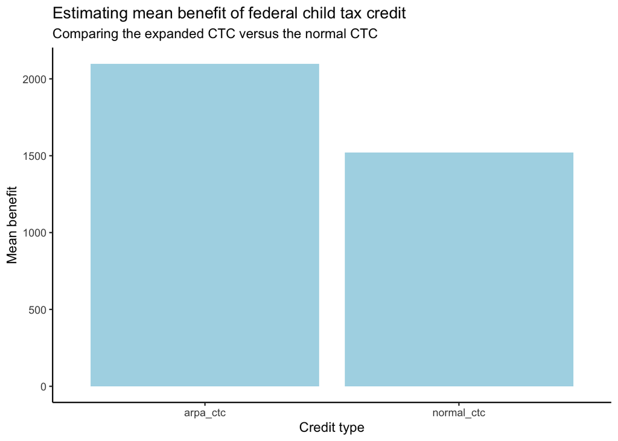

```r
normal_ctc <-
  normal_ctc %>%
  mutate(
    credit = "normal_ctc")

arpa_credit <-
  arpa_credit %>%
  mutate(
    credit = "arpa_ctc")

credits_combined <-
  bind_rows(normal_ctc, arpa_credit)

credits_combined %>%

  summarize(
    mean_benefit = mean(benefit),
    .by = credit) %>%

  ggplot() +
  geom_col(
    aes(x = credit,
        y = mean_benefit),
    fill = "#add8e6") +

  labs(
    title = "Estimating mean benefit of federal child tax credit",
    subtitle = "Comparing the expanded CTC versus the normal CTC",
    x = "Credit type",
    y = "Mean benefit") +

  theme_classic()
```